# DS01-IU 7-Nizam

Assessment : 07

Matplotlib Interactive Assignments

Question 1 :

To create a scatter graph using a random distribution in X and Y, you will need to write a program in Python. Plot the data against each other. ( You can use randn () )

Question 2: Perform Following task on given dataset.

Task 1: Read the data

Task 2 : Display it using a line plot and read out the total profit for all of the months.

Task 3: Determine the cumulative profit for all months and display it as a line plot using the following style properties.

It is recommended that the line style be dotted and the line color be red. Display the legend in the bottom right hand corner of the screen. Name of the label X = month number Y-label name = number of units sold Put a circle marker As read, the color of the line marker The line width should be 3 Task 4: Examine the monthly sales figures of toothpaste and present them in the form of a scatter plot. Task 5 : Read the monthly total profit and plot it on the histogram so that you can observe the most typical profit ranges.

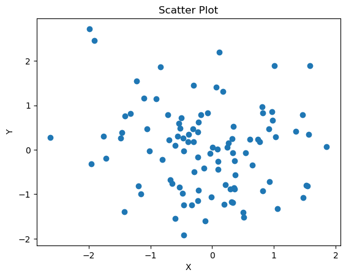

```python
#Question 1 :

#1.Importing libraries:

#numpy (imported as np) is a popular library for numerical computing in Python.
#It provides various functions to generate random numbers and perform mathematical operations efficiently.
#matplotlib.pyplot (imported as plt) is a module within the Matplotlib library that provides a MATLAB-like
#interface for creating plots and visualizations.

#2.Generating random data:

#np.random.seed(42) sets the seed for the random number
#generator to ensure reproducibility. It means that every time
#you run the code with the same seed, you'll get the same set of random numbers.
# n = 100 defines the number of data points we want to generate.
# x = np.random.randn(n) generates n random numbers
# from a standard normal distribution (mean=0, standard deviation=1) for the X values.
# y = np.random.randn(n) generates n random numbers from a standard normal distribution for the Y values.

#3.Creating the scatter plot:

#plt.scatter(x, y) creates a scatter plot by plotting the X
#and Y values against each other. Each point in the plot represents a pair of X and Y values.

#4.Adding labels and title:

#plt.xlabel('X') sets the label for the X-axis.
#plt.ylabel('Y') sets the label for the Y-axis.
#plt.title('Scatter Plot') sets the title for the plot.

#5.Displaying the plot:

#plt.show() displays the scatter plot on the screen.
#The code uses the randn() function from NumPy to generate
#random data from a standard normal distribution. The scatter plot
#visually represents the relationship between the X and Y values,
#allowing us to observe any patterns or correlations between the variables.


import numpy as np
import matplotlib.pyplot as plt

# Generate random data
np.random.seed(42)  # Set seed for reproducibility
n = 100  # Number of data points
x = np.random.randn(n)  # Random X values
y = np.random.randn(n)  # Random Y values

# Create scatter plot
plt.scatter(x, y)

# Add labels and title
plt.xlabel('X')
plt.ylabel('Y')
plt.title('Scatter Plot')

# Display the plot
plt.show()
```

```python
#Question 2 :

#Task 1: Read the data

#imported the required libraries (pandas, numpy, matplotlib.pyplot, and seaborn)
#and read a dataset called "Dataset_mat(1) 1.csv" into a pandas DataFrame called
#Dataset_mat. The dataset appears to have columns named "Month", "Toothpaste", "Soap", "Shampoo", and "Total_profit".

import pandas as pd
import numpy as np
import matplotlib.pyplot as plt
import seaborn as sns

Dataset_mat = pd.read_csv('Dataset_mat(1) 1.csv')
#print 5 column

print(Dataset_mat.head())
```

```
   Month  Toothpaste  Soap  Shampoo  Total_profit
0      1        5200  6100     8300         14000
1      2        5100  6200     8400         14500
2      3        5900  5800     8200         14600
3      4        7200  7400     8600         15200
4      5        8300  6900     8300         16000
```

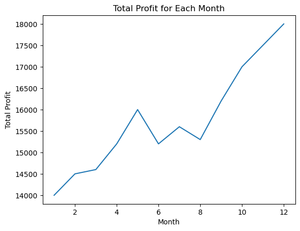

```
Total Profit for all Months: 189100
```

```python
#Task 2 : Display it using a line plot and read out the total profit for all of the months

#In this code, we use plt.plot() to create a line plot with the months (x-axis)
#plotted against the total profit (y-axis) from the Dataset_mat DataFrame.

#We then add labels and a title to the plot using plt.xlabel(),
#plt.ylabel(), and plt.title(), respectively.

#Finally, we display the line plot using plt.show()

#To calculate the total profit for all months, we use the sum()
#function on the 'Total_profit' column of the DataFrame. The result is
#stored in the total_profit variable, which is then printed using print().

#Make sure you have imported the necessary libraries (matplotlib.pyplot)
#and that the column names in the DataFrame ('Month' and 'Total_profit')
#match the ones used in the code.




# Create a line plot
plt.plot(Dataset_mat['Month'], Dataset_mat['Total_profit'])

# Add labels and title
plt.xlabel('Month')
plt.ylabel('Total Profit')
plt.title('Total Profit for Each Month')

# Display the line plot
plt.show()

# Calculate the total profit for all months
total_profit = Dataset_mat['Total_profit'].sum()
print("Total Profit for all Months:", total_profit)
```

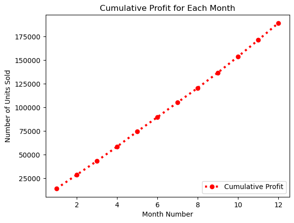

```python
#Task 3: Determine the cumulative profit for all months and display it as a line plot using the following style properties.

#In this code, we have made the following modifications to meet your requirements:

#Line style: linestyle=':' sets the line style to dotted.
#Line color: color='red' sets the line color to red.
#Legend: plt.legend(['Cumulative Profit'], loc='lower right')
#adds a legend with the label 'Cumulative Profit' and positions it in the lower right corner of the plot.

#X-label: plt.xlabel('Month Number') sets the X-axis label to 'Month Number'.
#Y-label: plt.ylabel('Number of Units Sold') sets the Y-axis label to 'Number of Units Sold'.
#Line marker: marker='o' adds a circular marker at each data point.
#Line width: linewidth=3 sets the line width to 3 pixels.

#imported the necessary libraries (matplotlib.pyplot) and that
#the column names in the DataFrame ('Month' and 'Total_profit') match the ones used in the code.


# Calculate the cumulative profit
cumulative_profit = Dataset_mat['Total_profit'].cumsum()

# Set the style properties
plt.plot(Dataset_mat['Month'], cumulative_profit, color='red', linestyle=':', marker='o', linewidth=3)

# Add labels and title
plt.xlabel('Month Number')
plt.ylabel('Number of Units Sold')
plt.title('Cumulative Profit for Each Month')

# Display the legend in the bottom right corner
plt.legend(['Cumulative Profit'], loc='lower right')

# Display the line plot
plt.show()
```

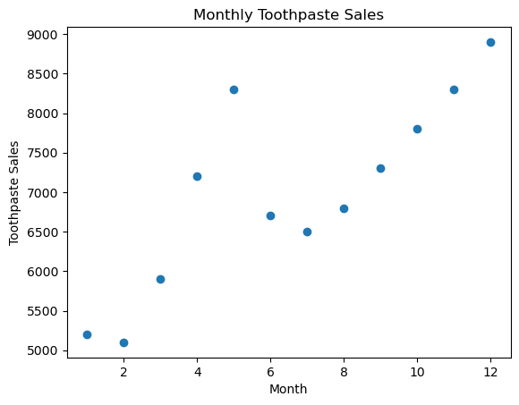

```python
#Task 4: Examine the monthly sales figures of toothpaste and present them in the form of a scatter plot.

#e extract the toothpaste sales data from the Dataset_mat DataFrame by accessing
# the 'Toothpaste' column and assigning it to the toothpaste_sales variable.

#Next, we create a scatter plot using plt.scatter() by passing the
#month values from the 'Month' column of the DataFrame as the X-axis
#and the toothpaste sales data as the Y-axis.

#We add labels to the plot using plt.xlabel() and plt.ylabel()
#to specify the X-axis and Y-axis labels, respectively. The
#plt.title() function is used to provide a title for the plot.




import matplotlib.pyplot as plt

# Extract toothpaste sales data
toothpaste_sales = Dataset_mat['Toothpaste']

# Create a scatter plot
plt.scatter(Dataset_mat['Month'], toothpaste_sales)

# Add labels and title
plt.xlabel('Month')
plt.ylabel('Toothpaste Sales')
plt.title('Monthly Toothpaste Sales')

# Display the scatter plot
plt.show()
```

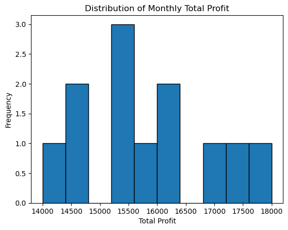

```python
#Task 5 : Read the monthly total profit and plot it on the histogram so that you can observe the most typical profit ranges.


#extract the monthly total profit data from the Dataset_mat DataFrame
#by accessing the 'Total_profit' column and assigning it to the monthly_profit variable.

#create a histogram using plt.hist() by passing the monthly profit data to it.
#The bins parameter specifies the number of bins (bars) in the histogram,
#and the edgecolor parameter sets the color of the edges of the bars.

#We add labels to the plot using plt.xlabel() and plt.ylabel()
#to specify the X-axis and Y-axis labels, respectively. The
#plt.title() function is used to provide a title for the plot.




# Extract the monthly total profit
monthly_profit = Dataset_mat['Total_profit']

# Create a histogram
plt.hist(monthly_profit, bins=10, edgecolor='black')

# Add labels and title
plt.xlabel('Total Profit')
plt.ylabel('Frequency')
plt.title('Distribution of Monthly Total Profit')

# Display the histogram
plt.show()
```